# Projekt zaliczeniowy

Karolina Kominiak

pierwszy semestr roku akademickiego 2022/2023

## Wstęp

W swojej prezentacji postanowiłam rozważyć bazę danych dotyczącą chorób serca u pacjentów pewnego szpitala w Cleeveland na oddziale kardiologincznym w danym miesiącu. Pochodzi ona ze strony internetowej UCI Machine Learning Repository, a link do niej znajduje się [tutaj](https://archive.ics.uci.edu/ml/machine-learning-databases/heart-disease/).

W swoich obliczeniach jako populację przyjmuję tych właśnie pacjentów.

W kolejnym slajdzie podaję informacje, które znajdziemy w bazie.

## Kolumny

- Wiek
- Płeć
- Rodzaj bólu klatki piersiowej
- Ciśnienie krwi podczas spoczynku
- Cholesterol w surowicy
- Poziom cukru we krwi na czczo
- EKG przy spoczynku
- Maksymalne osiągnięte tętno
- Dławica wywołana ćwiczeniami
- Ćwiczenie przy obniżeniu odcinka ST
- Szczytowy odcinek ST podczas ćwiczenia
- Liczba głównych naczyń we fluoroskopii
- Talasemia
- Pewność diagnozy choroby serca

## Opis danych

W mojej prezentacji skupię się na kolumnach “Cholesterol w surowicy” (podany w mg/dl), “Pewność diagnozy choroby serca” (podana w skali 0-4, gdzie 0 oznacza brak pewności występowania choroby, a 4 oznacza stuprocentową pewność), “Ciśnienie krwi podczas spoczynku” podane w mmHg, oraz “Płeć” (oznaczona 0 - kobieta, 1 - mężczyzna) i “Wiek” w celu rozważenia występowania poszczególnych zjawisk pośród przedstawicieli różnych grup

## Wykres liniowy wieku pacjentów, u których zdiagnozowano pewną chorobę serca

Za pomocą wykresu liniowego możemy przedstawić wiek pacjentów, u których zdiagnozowano pewną chorobę serca (przyjmujemy, że jest to taka, dla której pewność jest większa od lub równa 3, zatem 3 lub 4).

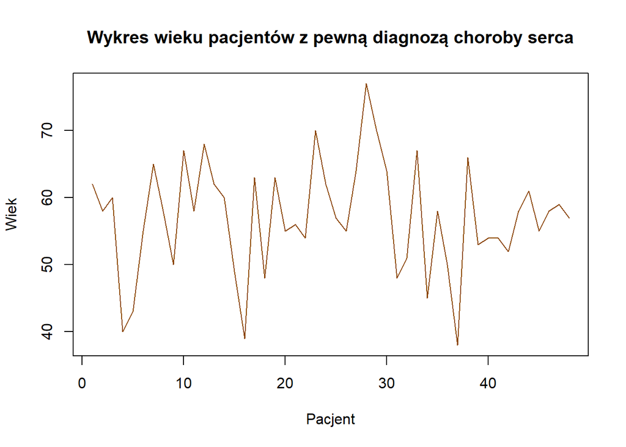

Z wykresu możemy wyczytać, że zdecydowana większość tych pacjentów to osoby powyżej 50. roku życia

## Cholesterol

Cholesterol jest substancją z grupy lipidów. Tak zwany dobry cholesterol, HDL, między innymi buduje błony komórkowe, bierze udział w wytwarzaniu witaminy D i hormonów oraz wspomaga prawidłowe działanie mózgu. Jak powszechnie jednak wiadomo, istnieje również tzw. zły cholesterol, LDL, który mimo bycia niezbędnym do prawidłowego funkcjonowania komórek naszego organizmu, w nadmiernej ilości może przyczynić się do wielu chorób serca. W mojej prezentacji skupię się głównie na przeanalizowaniu danych dotyczących poziomu cholesterolu oraz jego związku z innymi czynnikami.

## Obliczenia do statystyk opisowych dla kolumny “Cholesterol w surowicy”

Dla naszej wybranej kolumny obliczamy następujące wartości:

- Wartość minimalna: 126 mg/dl
- Wartość maksymalna: 564 mg/dl
- Wartość średnia: 246.7384106 mg/dl
- Mediana: 241.5 mg/dl
- Podział na kwartyle:
  - 25% - 211 mg/dl
  - 50% - 241.5 mg/dl
  - 75% - 275 mg/dl
  - 100% - 564 mg/dl

## Dalsze obliczenia

- Rozstęp: 438 mg/dl
- Wariancja: 2689.1306792 mg/dl
- Odchylenie standardowe: 51.8568287 mg/dl
- Odchylenie przeciętne od mediany: 48.1845 mg/dl

## Wnioski

Aby zobaczyć, z jakim zakresem obserwacji mamy do czynienia, obliczyliśmy **rozstęp**, który wyniósł 438 mg/dl, z czego dowiedzieliśmy się, że zakres jest bardzo duży. Biorąc to pod uwagę, możemy spodziewać się, że również **wariancja** naszych obserwacji będzie duża - i faktycznie, wynosi ona aż 2689.1306792 mg/dl, co oznacza, że wartości w naszym zbiorze są bardzo zróżnicowane. **Odchylenie standardowe** informuje nas o tym, jak szeroko wartości poziomu cholesterolu u naszych pacjentów są “rozrzucone” wokół jej średniej. W naszym przypadku wynosi 51.8568287 mg/dl, dowiadujemy się zatem, że badane wartości nie są skupione blisko średniej. Zbadaliśmy także **medianowe odchylenie bezwzględne**, dzięki któremu dowiedzieliśmy się, że wartości poziomu cholesterolu odchylają się znacznie także od mediany.

## Przedział ufności dla średniej

Badamy próbę losowo wybranych 10 pacjentów z populacji złożonej z 48 osób, u których wykryto pewną chorobę serca (poziom pewności 3 lub 4).

Średnia wieku pacjentów z próby wynosi 52.6. Sprawdzimy, jak średnia wieku pacjentów z próby odnosi się do średniej wieku wszystkich pacjentów populacji.

Jako poziom istotności przyjmujemy alfa = 0.05

Otrzymujemy przedział ufności dla średniej pomiędzy 46.3345552 do 58.8654448, a więc zgodnie z definicją przedziału ufności możemy stwierdzić, że z założonym przez nas prawdopodobieństwem, średnia wieku populacji pacjentów wyniesie między 46.3345552 lat do 58.8654448 lat.

## Zdrowy poziom cholesterolu - minimalna liczebność próby

U zdrowego człowieka wartość cholesterolu w osoczu nie powinna przekraczać 200 mg/dl. Możemy zbadać związek podwyższonego cholesterolu z pozostałymi parametrami.

Wyodrębniamy z naszej populacji grupę pacjentów, których poziom cholesterolu przekracza zdrową normę. Wynosi ona 253.

Chcemy zbadać średnie ciśnienie krwi podczas spoczynku u tych pacjentów. Zakładamy, że nie mamy możliwości przeprowadzenia naszych badań na wszystkich pacjentach, wobec tego musimy wybrać spośród nich próbę.

Czy do naszych badań próba złożona ze 130 pacjentów będzie wystarczająca, jeśli chcemy utrzymać wartość przyjętego błedu na poziomie mniejszym niż 0.1, zakładając współczynnik alfa = 0.05?

Z wykonanych obliczeń uzyskujemy wynik równy 95.9629529, który jest mniejszy od zakładanego 130, zatem możemy stwierdzić, że próba jest wystarczająca.

## Analiza wariancji

Rozpatrujemy 4 grupy złożone z losowo wybranych 15 pacjentów pod kątem podwyższonego poziomu cholesterolu: kobiety poniżej 50. roku życia (K1), kobiety w wieku 50 lat i powyżej (K2), mężczyźni poniżej 50. roku życia (M1) i mężczyźni w wieku 50 lat i powyżej (M2). W tym celu przeprowadzimy dwuczynnikową analizę wariancji, przyjmując jako czynnik A płeć pacjentów, a jako czynnik B ich grupę wiekową. Stawiamy następujące hipotezy:

- Hipoteza zerowa A: płeć pacjentów nie ma wpływu na poziom cholestrolu
- Hipoteza zerowa B: wiek pacjentów nie ma wpływu na poziom cholesterolu
- Dodatkowa hipoteza zerowa AB: płeć i wiek pacjentów nie mają wpływu na poziom cholesterolu

## Wykres do analizy wariancji

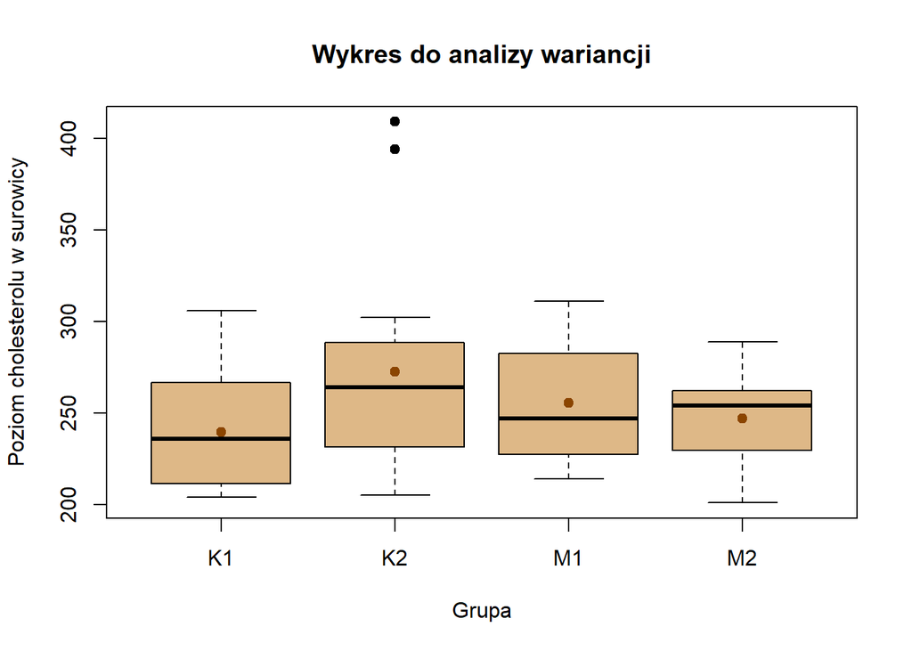

## Analiza wariancji #2

Chcemy sprawdzić słuszność postawionych wcześniej hipotez. W tym celu korzystamy najpierw z funkcji aov(). Przyjmujemy jako poziom istotności alfa = 0.05. Obliczamy również wartość krytyczną.

- Wartość obliczona:

```r
summary(wynik.aov)
```

```
##                   Df Sum Sq Mean Sq F value Pr(>F)
## plec               1    350     350   0.219  0.641
## wiekpacjenta       1   3182    3182   1.992  0.164
## plec:wiekpacjenta  1   4310    4310   2.698  0.106
## Residuals         56  89465    1598
```

- Wartość krytyczna: 2.7694309

## Test parametryczny - średnia wieku osób z podwyższonym cholesterolem

Za pomocą testu parametrycznego możemy zbadać prawdziwość poniższej hipotezy:

- Hipoteza zerowa: średnie wieku mężczyzn z podwyższonym cholesterolem i kobiet z podwyższonym cholesterolem nie różnią się od siebie znacznie.
- Hipoteza alternatywna: średnie wieku mężczyzn z podwyższonym cholesterolem i kobiet z podwyższonym cholesterolem różnią się od siebie znacznie.

Zakładamy, że alfa = 0.05.

```
## [1] 56.0241
```

```
## [1] 54.40588
```

```
##
##  Welch Two Sample t-test
##
## data:  kobzpodwchol$Wiek and mezzpodwchol$Wiek
## t = 1.3882, df = 158.95, p-value = 0.167
## alternative hypothesis: true difference in means is not equal to 0
## 95 percent confidence interval:
##  -0.6839786  3.9204066
## sample estimates:
## mean of x mean of y
##  56.02410  54.40588
```

Ponieważ p-value naszego testu wynosi 0.167, co jest wartością większą niż założone alfa (0.05), nie mamy podstaw do odrzucenia hipotezy zerowej.

## Cholesterol - test normalności

Możemy także zbadać normalność rozkładu wartości kolumny “Cholesterol w surowicy”. W tym celu przeprowadzimy test Shapiro-Wilka, stawiając następujące hipotezy:

- Hipoteza zerowa: wartości poziomu cholesterolu we krwi są z rozkładu normalnego
- Hipoteza alternatywna: wartości poziomu cholesterolu we krwi nie są z rozkładu normalnego

```
##
##  Shapiro-Wilk normality test
##
## data:  test
## W = 0.9475, p-value = 6.603e-09
```

Ponieważ obliczona wartość p-value wynosi 6.603e-09, czyli jest mniejsza od założonego alfa (0.05), hipotezę zerową o normalności rozkładu należy odrzucić.

Ilustrujemy nasze wyniki na histogramie.

## Histogram rozkładu wartości cholesterolu we krwi

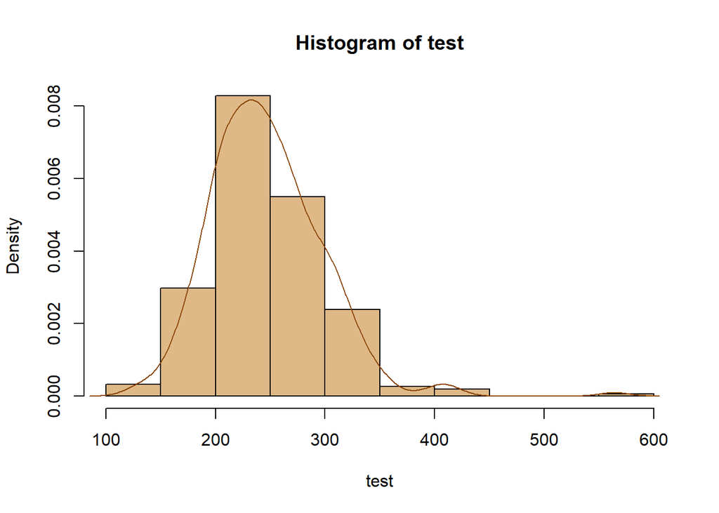

Na histogramie widzimy dokładnie, że nie mamy do czynienia z wykresem Gaussa, co tym bardziej może utwierdzić nas w przekonaniu, że zmienne nie są z rozkładu normalnego.

## Podsumowanie

**Serdecznie dziękuję za uwagę!**